# STAT430 Final Report

by Keyu Chen

## Section 1: Dataset description

**1. COVID-19 Vaccinations in the United States,Jurisdiction**

Overall US COVID-19 Vaccine deliveries and administration data at national and jurisdiction level. Data represents all vaccine partners including jurisdictional partner clinics, retail pharmacies, long-term care facilities, dialysis centers, Federal Emergency Management Agency and Health Resources and Services Administration partner sites, and federal entity facilities.

The variables used are:

- Date
- Series_Complete_Pop_Pct: Percent of people who are fully vaccinated (have second dose of a two-dose vaccine or one dose of a single-dose vaccine) based on the jurisdiction where recipient lives.
- Administered_Dose1_Pop_Pct: Percent of population with at lease one dose based on the jurisdiction where recipient lives.
- Location: State/Territory/Federal Entity.

**2. COVID-19 Vaccinations in the United States,County**

Overall US COVID-19 Vaccine administration and vaccine equity data at county level. Data represents all vaccine partners including jurisdictional partner clinics, retail pharmacies, long-term care facilities, dialysis centers, Federal Emergency Management Agency and Health Resources and Services Administration partner sites, and federal entity facilities.

The variables used are:

- Date
- Recip_County: Recipient County.
- Series_Complete_Pop_Pct: Percent of people who are fully vaccinated (have second dose of a two-dose vaccine or one dose of a single-dose vaccine) based on the jurisdiction and county where recipient lives.
- Administered_Dose1_Pop_Pct: Percent of Total Pop with at least one Dose by State of Residence.
- Recip_State: Recipient State.

**3. United States COVID-19 County Level of Community Transmission as Originally Posted**

This public use dataset has 7 data elements reflecting community transmission levels for all available counties. This dataset contains reported daily transmission level at the county level and contains the same values used to display transmission maps on the COVID Data Tracker. Each day, the dataset is appended to contain the most recent day's data. Transmission level is set to low, moderate, substantial, or high using the calculation rules below.

The variables used are:

- state_name: State.
- county_name: County.
- cases_per_100K_7_day_count_change: Total number of new cases per 100,000 persons within the last 7 days.
- percent_test_results_reported_positive_last_7_days: Percentage of positive diagnostic and screening nucleic acid amplification tests (NAAT) during the last 7 days.
- report_date: Date county level of community transmission indicator reported on COVID Data Tracker.

## Section 2: Question of interest (What is the goal of your web app)

My web app's goal is to build a Dash US Covid-19 data tracker using the above three US covid-19 dataset.

## Section 3: Testing of the web app (Explain how you test your web app and demonstrate with at least 1 example by using screenshots of the app)

Method of testing and at least 1 example:

I run my python file at my Anaconda terminal and it will return a HTTP link. By using this website link, I can see if the dash app runs correctly. If there is a bug, the website will not display anything; Anaconda terminal will also terminate automatically. However, if the bug is not serious, the HTTP website link will return warning messages and tell me what my errors are. I use these messages to fix my errors.

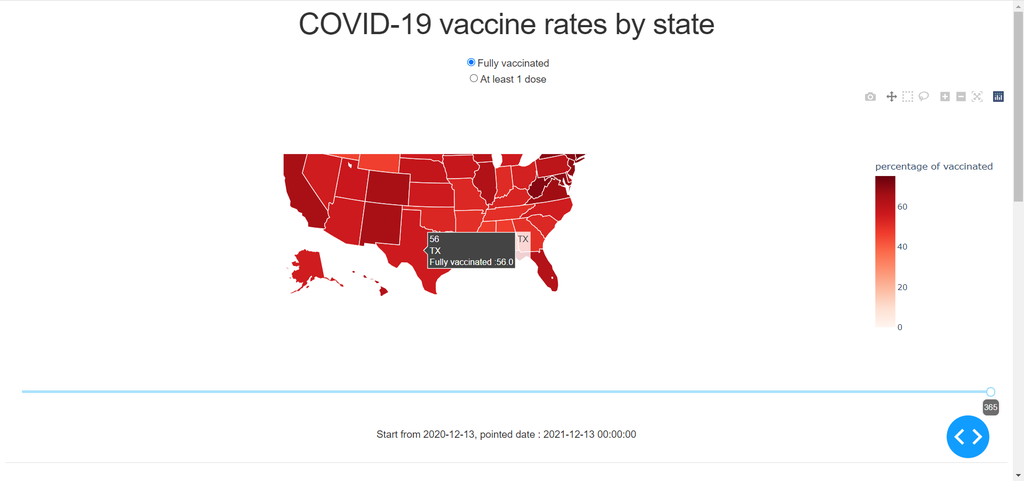

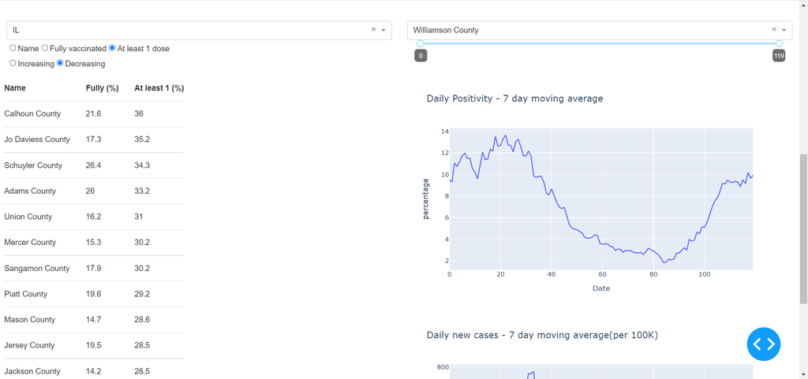

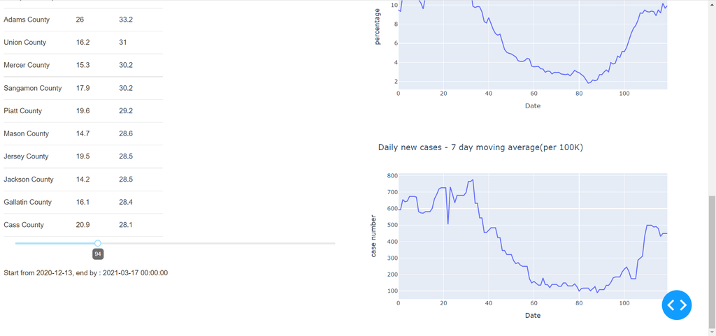

## Section 4: Conclusion & discussion (What did you do well? What could be improved? If someone is to continue working on your project, what should they tackle next?)

I completed the final project option #3 and met all the requirements set by Prof Nguyen. This fulfilled my initial goal of creating a US COVID-19 Data Tracker.

The website can be improved by adding more plots as not all the variables are used in the provided dataset.

If someone is to continue working on my project, I think this person can make my dash website look more fancier and expand on this project by plotting more interactive graphs.